# Cluster the documents

Lincoln Mullen

November 5, 2015

We are going to create clusters of our documents using the affinity propagration algorithm.

Our data is bigger than anticipated when the number of section by section comparisons is stored as a non-sparse matrix. So we are going to read in the section comparisons and convert them to a sparse matrix.

```r
library("Matrix")
library("apcluster")
library("dplyr")
library("readr")
library("textreuse")
source("R/helper.R")
load("cache/corpus-lsh.rda")
```

Filter the sections down to a meaningful value.

```r
scores_clustering <- scores %>%
  filter(score >= 0.1)
scores_clustering
```

```
## Source: local data frame [310,531 x 3]
##
##                a             b     score
##            (chr)         (chr)     (dbl)
## 1  AK1900-000010 AR1868-000060 0.2133333
## 2  AK1900-000010 AR1874-000090 0.3684211
## 3  AK1900-000010 AZ1865-000020 0.2096774
## 4  AK1900-000010 CA1850-000030 0.1764706
## 5  AK1900-000010 CA1851-000030 0.1194030
## 6  AK1900-000010 CA1858-000030 0.2096774
## 7  AK1900-000010 CA1868-000030 0.1194030
## 8  AK1900-000010 CA1872-002310 0.1935484
## 9  AK1900-000010 CO1877-000010 0.1730769
## 10 AK1900-000010 DC1857-000980 0.4054054
## ..           ...           ...       ...
```

```r
nrow(scores_clustering)
```

```
## [1] 310531
```

Get the sections involved:

```r
section_names <- lsh_subset(scores_clustering)
head(section_names, 10)
```

```
##  [1] "AK1900-000010" "AK1900-000020" "AK1900-000050" "AK1900-000060"
##  [5] "AK1900-000070" "AK1900-000080" "AK1900-000090" "AK1900-000100"
##  [9] "AK1900-000110" "AK1900-000120"
```

```r
length(section_names)
```

```
## [1] 60381
```

Create a look up data frame of matrix index positions.

```r
lookup <- data_frame(section_names, index = 1:length(section_names))
lookup
```

```
## Source: local data frame [60,381 x 2]
##
##    section_names index
##            (chr) (int)
## 1  AK1900-000010     1
## 2  AK1900-000020     2
## 3  AK1900-000050     3
## 4  AK1900-000060     4
## 5  AK1900-000070     5
## 6  AK1900-000080     6
## 7  AK1900-000090     7
## 8  AK1900-000100     8
## 9  AK1900-000110     9
## 10 AK1900-000120    10
## ..           ...   ...
```

```r
scores_clustering <- scores_clustering %>%
  left_join(lookup, by = c("a" = "section_names")) %>%
  left_join(lookup, by = c("b" = "section_names"))
scores_clustering
```

```
## Source: local data frame [310,531 x 5]
##
##                a             b     score index.x index.y
##            (chr)         (chr)     (dbl)   (int)   (int)
## 1  AK1900-000010 AR1868-000060 0.2133333       1     990
## 2  AK1900-000010 AR1874-000090 0.3684211       1    1805
## 3  AK1900-000010 AZ1865-000020 0.2096774       1    2153
## 4  AK1900-000010 CA1850-000030 0.1764706       1    3376
## 5  AK1900-000010 CA1851-000030 0.1194030       1    3604
## 6  AK1900-000010 CA1858-000030 0.2096774       1    4280
## 7  AK1900-000010 CA1868-000030 0.1194030       1    4966
## 8  AK1900-000010 CA1872-002310 0.1935484       1    5842
## 9  AK1900-000010 CO1877-000010 0.1730769       1    7429
## 10 AK1900-000010 DC1857-000980 0.4054054       1    8300
## ..           ...           ...       ...     ...     ...
```

Create the sparse matrix.

```r
n <- length(section_names)
m <- sparseMatrix(i = scores_clustering$index.x,
                  j = scores_clustering$index.y,
                  x = scores_clustering$score,
                  dims = c(n, n), symmetric = TRUE)
colnames(m) <- section_names
rownames(m) <- section_names
```

Now use affinity propagation clustering to create clusters.

```r
cluster_cache <- "cache/clusters.rds"
if (!file.exists(cluster_cache)) {
  timing <- system.time(
    clu <- apcluster(s = m,
                     maxits = 100e3, convits = 10e3,
                     q = 0,
                     lam = 0.975,
                     seed = 42325,
                     includeSim = TRUE,
                     )
  )
  require("RPushbullet")
  pbPost(title = "Clustering finished",
         body = paste0("Finished in ", timing[["elapsed"]], "."))
  saveRDS(clu, cluster_cache)
} else {
  clu <- readRDS(cluster_cache)
}
```

Get the clusters in a slightly easier format to work with.

```r
clusters <- clu@clusters
names(clusters) <- names(clu@exemplars)
clusters <- lapply(clusters, names)
```

Now the problem is that some clusters have been inadequately joined together. We will compute simiarities on the examplars. If any of them have a high Jaccard similarity, we will join those clusters together.

```r
exemplars_corpus <- sections[names(clusters)]
exemplars_scores <- exemplars_corpus %>%
  lsh(bands = 60) %>%
  lsh_candidates() %>%
  lsh_compare(exemplars_corpus, jaccard_similarity) %>%
  arrange(desc(score))
```

Here is a box plot of those scores:

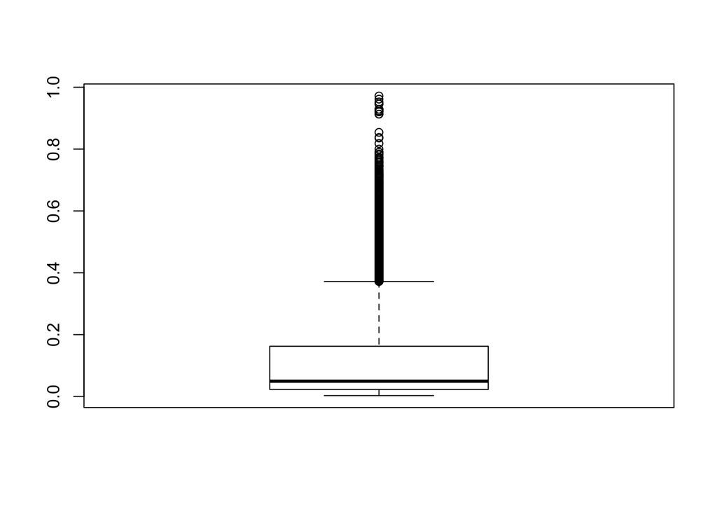

```r
boxplot(exemplars_scores$score)
```

What is a good minimum match? Looking at the sections, `0.2` is clearly a match, while `0.1` is clearly not. An important observation is that the exemplars for the blood quantum sections have a Jaccard similarity of `0.15`. We will use that as the threshold.

```r
join_threshold <- 0.15
exemplars_scores <- exemplars_scores %>%
  filter(score >= 0.15)
```

Now a function to iterate over that data frame. If the Jaccard score is sufficiently high, combine the two clusters.

```r
join_clusters <- function(row) {
  exs <- c(row$a, row$b)
  minval <- which.min(extract_date(exs))
  exemplar <- exs[minval]
  duplicate <- exs[ifelse(minval == 1, 2, 1)]
  clusters[[exemplar]] <<- c(clusters[[exemplar]], clusters[[duplicate]])
  clusters[[duplicate]] <<- NULL
  dplyr::as_data_frame(row)
}

exemplars_scores %>%
  rowwise() %>%
  do(join_clusters(.))
```

```
## Source: local data frame [3,639 x 3]
## Groups: <by row>
##
##                a             b     score
##            (chr)         (chr)     (dbl)
## 1  AK1900-008630 OR1862-012840 0.9718310
## 2  AK1900-004560 OR1862-005180 0.9615385
## 3  NY1850-001210 NY1853-001050 0.9523810
## 4  KS1868-006440 OK1893-007390 0.9459459
## 5  NY1850-003410 NY1853-003240 0.9459459
## 6  DT1887-000500 ND1877-000370 0.9285714
## 7  NY1850-012960 NY1853-012790 0.9285714
## 8  WI1849-012930 WI1858-008910 0.9285714
## 9  IN1852-004810 OK1891-005300 0.9230769
## 10 NY1850-013990 NY1853-013790 0.9230769
## ..           ...           ...       ...
```

Now convert the clusters into a data frame.

```r
clusters_df <- clusters %>%
  seq_along() %>%
  lapply(function(i) {
    exemplar <- names(clusters)[i]
    doc <- clusters[[i]]
    data_frame(exemplar, doc, cluster_id = i)
  }) %>%
  bind_rows() %>%
  mutate(exemplar_year = extract_date(exemplar),
         doc_date = extract_date(doc)) %>%
  group_by(cluster_id) %>%
  mutate(earliest_date = min(doc_date),
         earliest = doc[which.min(doc_date)]) %>%
  select(cluster_id, exemplar, exemplar_year, earliest, earliest_date,
         doc, doc_date) %>%
  arrange(doc_date) %>%
  mutate(n = n()) %>%
  ungroup() %>%
  arrange(desc(n))
clusters_df
```

```
## Source: local data frame [57,967 x 8]
##
##    cluster_id      exemplar exemplar_year      earliest earliest_date
##         (int)         (chr)         (int)         (chr)         (int)
## 1        4282 KY1854-001630          1854 NY1848-001930          1848
## 2        4282 KY1854-001630          1854 NY1848-001930          1848
## 3        4282 KY1854-001630          1854 NY1848-001930          1848
## 4        4282 KY1854-001630          1854 NY1848-001930          1848
## 5        4282 KY1854-001630          1854 NY1848-001930          1848
## 6        4282 KY1854-001630          1854 NY1848-001930          1848
## 7        4282 KY1854-001630          1854 NY1848-001930          1848
## 8        4282 KY1854-001630          1854 NY1848-001930          1848
## 9        4282 KY1854-001630          1854 NY1848-001930          1848
## 10       4282 KY1854-001630          1854 NY1848-001930          1848
## ..        ...           ...           ...           ...           ...
## Variables not shown: doc (chr), doc_date (int), n (int)
```

That data frame has the following properties. It is sorted so that the clusters with the most documents appear first. Within each cluster, documents appear chronologically. Each cluster contains three columns for documents (with another three columns corresponding to years). One column is the “examplar” document identified by the affinity propagation clustering. The next is the earliest document in the cluster. If there are multiple documents from the earliest year, then only one is listed. The third is a list of all the documents in the cluster. The column `n` is the number of documents in the cluster. All clusters regardless of length have been included.

Write that to disk:

```r
dir.create("out/clusters")
write_csv(clusters_df, "out/clusters/clusters.csv")
```

Some summary statistics about the borrowings.

The codes which most frequently provide exemplars, weighted by the size of the clusters for which they are exemplars.

```r
exemplars_summary <- clusters_df$exemplar %>%
  extract_code_names() %>%
  table() %>%
  as.data.frame() %>% as_data_frame() %>%
  rename(., code = `.`) %>%
  arrange(desc(Freq))
write_csv(exemplars_summary, "out/clusters-exemplars-summary.csv")
exemplars_summary %>% head(20)
```

```
## Source: local data frame [20 x 2]
##
##      code  Freq
##    (fctr) (int)
## 1  NY1850  6109
## 2  CA1851  2854
## 3  IA1851  2270
## 4  CA1858  1941
## 5  CA1872  1826
## 6  MN1859  1718
## 7  KY1851  1628
## 8  DT1862  1561
## 9  WI1849  1533
## 10 NY1876  1520
## 11 NY1849  1464
## 12 NY1853  1410
## 13 NE1855  1335
## 14 IN1852  1278
## 15 WV1868  1251
## 16 OH1853  1235
## 17 MA1836  1122
## 18 NY1851  1011
## 19 NY1879   946
## 20 NE1859   930
```

The codes which most frequently provide the earliest documents in the clusters, weighted by the size of the clusters for which they are the earliest.

```r
earliest_summary <- clusters_df$earliest %>%
  extract_code_names() %>%
  table() %>%
  as.data.frame() %>% as_data_frame() %>%
  rename(., code = `.`) %>%
  arrange(desc(Freq))
write_csv(earliest_summary, "out/clusters-earliest-summary.csv")
earliest_summary %>% head(20)
```

```
## Source: local data frame [20 x 2]
##
##      code  Freq
##    (fctr) (int)
## 1  NY1850  8824
## 2  NY1848  7554
## 3  NY1829  4220
## 4  KY1851  3971
## 5  OH1853  3689
## 6  IA1851  3460
## 7  CA1851  2597
## 8  CA1872  2447
## 9  NY1876  2329
## 10 MA1836  1851
## 11 NY1849  1759
## 12 IN1852  1583
## 13 WI1849  1351
## 14 VA1860   938
## 15 OR1862   708
## 16 IN1843   586
## 17 OH1879   454
## 18 MO1835   438
## 19 FL1847   437
## 20 WV1868   435
```

Now let’s write out the clusters with a certain minimum number of documents to disk.

```r
unlink("clusters", recursive = TRUE)
dir.create("clusters", showWarnings = FALSE)

get_printable_code <- function(doc_id) {
  require("stringr")
  content <- str_wrap(content(sections[[doc_id]]))
  str_c(doc_id, content, "-----------------------------------------------\n\n",
        sep = "\n\n")
}

get_cluster_header <- function(exemplar, earliest, n, cluster_id) {
  require("stringr")
  str_c("Exemplar: ", exemplar, "\n",
        "Earliest: ", earliest, "\n",
        "Documents in cluster: ", n, "\n",
        "Cluster ID: ", cluster_id, "\n",
        "\n",
        "-----------------------------------------------\n\n")
}

write_cluster <- function(df) {
  require("stringr")
  exemplar <- unique(df$exemplar)
  earliest <- unique(df$earliest)
  n <- unique(df$n)
  cluster_id <- unique(df$cluster_id)
  header <- get_cluster_header(exemplar, earliest, n, cluster_id)
  docs <- df$doc %>% sapply(get_printable_code)
  text <- str_c(docs, collapse = "\n") %>%
    str_c(header, .) %>%
    str_split("\n") %>%
    unlist()
  filename <- str_c("clusters/", earliest, ".txt")
  message("Writing ", filename)
  writeLines(text, filename)
  df
}

clusters_df %>%
  filter(n >= 5) %>%
  group_by(cluster_id) %>%
  do(write_cluster(.))
```

```
## Source: local data frame [33,013 x 8]
## Groups: cluster_id [2897]
##
##    cluster_id      exemplar exemplar_year      earliest earliest_date
##         (int)         (chr)         (int)         (chr)         (int)
## 1          17 AK1900-001820          1900 NY1848-002770          1848
## 2          17 AK1900-001820          1900 NY1848-002770          1848
## 3          17 AK1900-001820          1900 NY1848-002770          1848
## 4          17 AK1900-001820          1900 NY1848-002770          1848
## 5          17 AK1900-001820          1900 NY1848-002770          1848
## 6          17 AK1900-001820          1900 NY1848-002770          1848
## 7          17 AK1900-001820          1900 NY1848-002770          1848
## 8          17 AK1900-001820          1900 NY1848-002770          1848
## 9          17 AK1900-001820          1900 NY1848-002770          1848
## 10         17 AK1900-001820          1900 NY1848-002770          1848
## ..        ...           ...           ...           ...           ...
## Variables not shown: doc (chr), doc_date (int), n (int)
```